# Fixed-effects models

Wen Fan

2025-09-18

# Install and load R packages

First, load the necessary libraries and the data. For this week and the following weeks, we will use the PSID data available [here](https://www.dropbox.com/scl/fi/sa44qdsocysjbz8h9sncs/psid.dta?rlkey=bwwfgglu41jbic6zfh6jev0ub&dl=0). The PSID (Panel Study of Income Dynamics) is a longitudinal household survey that has been ongoing since 1968, collecting data on various aspects of family life, including income, employment, health, and education. I include only a subset of the original data for demonstration purposes.

The key question we will explore is how changes in education (`yrsch`) and self-rated health (`srh`) affect changes in personal income (`pincome1`) over time, controlling for occupational prestige (`hwsei`).

```r
require(tidyverse)
require(haven)
require(sjPlot)
require(knitr)
require(plm)
require(fixest)
require(sandwich)
require(lmtest)
require(car)
```

```r
psid <- read_dta("/Users/wenfan/Library/CloudStorage/Dropbox/Longitudinal Data/psid.dta")
```

# Reshape data between long and wide formats

The PSID data are currently in long format, where each row represents an observation for a person in a specific year. We can reshape it to wide format if needed, but for fixed-effects models, we typically work with long format.

```r
# Long to wide
psid_wide <- psid |>
  pivot_wider(id_cols = id, names_from = year, values_from = c(yrsch, srh, pincome1, hwsei), names_sep = "_")

# Wide to long
psid_long <- psid_wide |>
  pivot_longer(cols = starts_with(c("yrsch_", "srh_", "pincome1_", "hwsei_")),
               names_to = c(".value", "year"),
               names_sep = "_")
```

# Checking within-person variation

Before running fixed-effects models, let’s first take a look at the data and check the within-person variation in key variables. Fixed-effects models rely on within-person changes over time to estimate effects, so it’s important to ensure that there is sufficient variation within individuals.

```r
# Data summary
head(psid, 10) |> kable(caption = "First 10 observations of PSID data")
```

First 10 observations of PSID data

| id | year | ykid | region | weight | srh | smk1 | noexe | limit | incomeadj | yrsch | emp | pincome1 | wrkhour | hwsei | marital | female | race | anykid | housewrk | k6new | age |
| --- | --- | --- | --- | --- | --- | --- | --- | --- | --- | --- | --- | --- | --- | --- | --- | --- | --- | --- | --- | --- | --- |
| 1001 | 1968 | 0 | 2 | 23 | NA | NA | NA | NA | 23365.418 | 7 | 4 | 1711 | 23.07692 | NA | 1 | 0 | 1 | 0 | NA | NA | 52 |
| 1001 | 1969 | 0 | 2 | 25 | NA | NA | NA | 1 | 10818.182 | 2 | 4 | 0 | 35.97239 | 35.07941 | 1 | 0 | 1 | 0 | NA | NA | 53 |
| 1001 | 1970 | 0 | 2 | 25 | NA | NA | NA | NA | NA | NA | NA | NA | NA | NA | NA | 0 | NA | NA | NA | NA | 54 |
| 1002 | 1968 | 0 | 2 | 23 | NA | NA | NA | NA | 23365.418 | 7 | NA | 3903 | 38.46154 | NA | 1 | 1 | NA | 0 | NA | NA | 46 |
| 1002 | 1969 | 0 | 2 | 25 | NA | NA | NA | NA | 10818.182 | NA | NA | 4063 | 38.46154 | 25.53000 | 1 | 1 | NA | 0 | NA | NA | 47 |
| 1002 | 1970 | 0 | 2 | 25 | NA | NA | NA | 0 | 9653.530 | 2 | 1 | 4979 | 40.38462 | 25.53000 | 3 | 1 | 1 | 0 | NA | NA | 48 |
| 1002 | 1971 | 0 | 2 | 25 | NA | NA | NA | 0 | 8273.865 | 2 | 1 | 5287 | 56.53846 | 25.53000 | 3 | 1 | 1 | 0 | NA | NA | 49 |
| 1002 | 1972 | 0 | 2 | 25 | NA | NA | NA | 0 | 6887.556 | 7 | 1 | 4594 | 38.46154 | 25.53000 | 3 | 1 | 1 | 0 | NA | NA | 50 |
| 1002 | 1973 | 0 | 2 | 25 | NA | NA | NA | 0 | 7538.574 | 7 | 1 | 5179 | 38.46154 | 25.53000 | 3 | 1 | 1 | 0 | NA | NA | 51 |
| 1002 | 1974 | 0 | 2 | 27 | NA | NA | NA | 0 | 7012.329 | 7 | 1 | 5119 | 38.30769 | 25.53000 | 3 | 1 | 1 | 0 | NA | NA | 52 |

```r
summary(psid[, c("yrsch", "srh", "pincome1")]) |>
  as.data.frame() |>
  kable(caption = "Summary statistics of key variables")
```

Summary statistics of key variables

| Var1 | Var2 | Freq |
| --- | --- | --- |
|  | yrsch | Min. : 0.00 |
|  | yrsch | 1st Qu.:11.00 |
|  | yrsch | Median :12.00 |
|  | yrsch | Mean :12.23 |
|  | yrsch | 3rd Qu.:15.00 |
|  | yrsch | Max. :17.00 |
|  | yrsch | NA’s :15828 |
|  | srh | Min. :1.00 |
|  | srh | 1st Qu.:3.00 |
|  | srh | Median :4.00 |
|  | srh | Mean :3.62 |
|  | srh | 3rd Qu.:4.00 |
|  | srh | Max. :5.00 |
|  | srh | NA’s :35172 |
|  | pincome1 | Min. : 0 |
|  | pincome1 | 1st Qu.: 0 |
|  | pincome1 | Median : 8600 |
|  | pincome1 | Mean : 19222 |
|  | pincome1 | 3rd Qu.: 25892 |
|  | pincome1 | Max. :1800000 |
|  | pincome1 | NA’s :18389 |

The following code calculates the within-person standard deviation and range. The results indicate that there is sufficient variability for fixed-effects estimation.

```r
# Check within-person variation
within_variation <- psid |>
  group_by(id) |>
  summarize(
    yrsch_sd = sd(yrsch, na.rm = TRUE),
    srh_sd = sd(srh, na.rm = TRUE),
    pincome1_sd = sd(pincome1, na.rm = TRUE),
    yrsch_rg = max(yrsch) - min(yrsch),
    srh_rg = max(srh) - min(srh),
    pincome1_rg = max(pincome1) - min(pincome1),
    .groups = 'drop' # Drop all grouping information to not interfere with future operations
  )

cat("Mean within-person SD in education:", round(mean(within_variation$yrsch_sd, na.rm = TRUE), 3))
```

```
## Mean within-person SD in education: 1.636
```

```r
cat("Mean within-person SD in self-reported health:", round(mean(within_variation$srh_sd, na.rm = TRUE), 3))
```

```
## Mean within-person SD in self-reported health: 0.611
```

```r
cat("Mean within-person SD in income:", round(mean(within_variation$pincome1_sd, na.rm = TRUE), 3))
```

```
## Mean within-person SD in income: 12878.49
```

We can also create a few exploratory plots to visualize within- versus between-individual variation. There appear to be some outliers with large incomes or income changes, which we may want to investigate further (though not here).

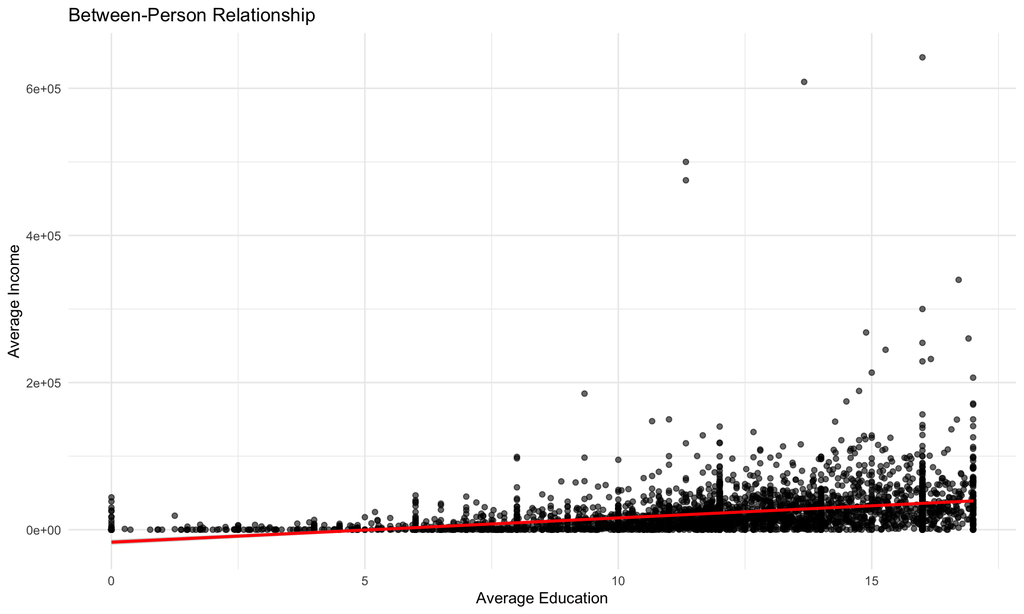

```r
# Between-person variation
between <- psid |>
  group_by(id) |>
  summarize(
    yrsch_mean = mean(yrsch, na.rm = TRUE),
    pincome1_mean = mean(pincome1, na.rm = TRUE),
    .groups = 'drop'
  )

p_between <- ggplot(between, aes(x = yrsch_mean, y = pincome1_mean)) +
  geom_point(alpha = 0.6) +
  geom_smooth(method = "lm", se = TRUE, color = "red") +
  labs(title = "Between-Person Relationship",
       x = "Average Education",
       y = "Average Income") +
  theme_minimal()

# Within-person changes (for those with education changes)
within <- psid |>
  arrange(id, year) |> # Sort data by id and time
  group_by(id) |>
  mutate(
    yrsch_ch = yrsch - dplyr::lag(yrsch, 1), # Make sure to add dplyr:: before lag to avoid confusion with lag from other packages
    pincome1_ch = pincome1 - dplyr::lag(pincome1, 1)
  ) |>
  ungroup() |> # Drop grouping
  filter(yrsch_ch != 0)

p_within <- ggplot(within, aes(x = yrsch_ch, y = pincome1_ch)) +
  geom_point(alpha = 0.6) +
  geom_smooth(method = "lm", se = TRUE, color = "blue") +
  labs(title = "Within-Person Changes",
       x = "Change in Education",
       y = "Change in Income") +
  theme_minimal()

print(p_between)
```

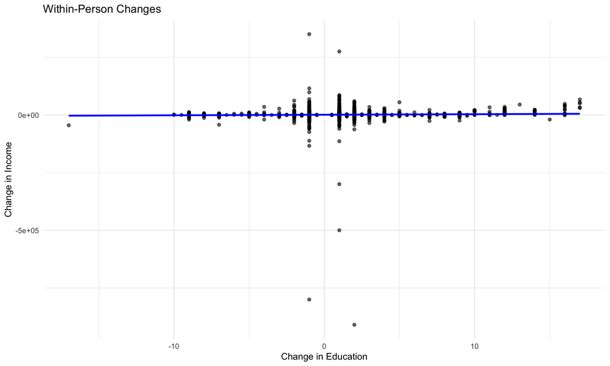

```r
print(p_within)
```

Before running the models, we will transform the income variable by taking the natural log to account for the skewed distribution of income. We will also add a small constant to avoid $log(0)$.

```r
psid <- psid |>
  mutate(log_pincome1 = log(pincome1 + 1))
```

# Running fixed-effects models

The `plm` package provides a straightforward way to estimate various panel data models, including fixed effects. For the package to recognize the panel structure, we need to first set up the data in panel format using `pdata.frame()`.

```r
# Convert to panel data format for plm package
psid_plm <- pdata.frame(psid, index = c("id", "year"))
```

Specifying `model = "within"` in the `plm()` function tells R to estimate a fixed-effects model using the within transformation approach.

```r
# Fixed effects model
fe_plm <- plm(log_pincome1 ~ yrsch + srh + hwsei, data = psid_plm, model = "within")
tab_model(fe_plm)
```

|  | log_pincome1 |  |  |
| --- | --- | --- | --- |
| Predictors | Estimates | CI | p |
| yrsch | 0.04 | -0.01 – 0.10 | 0.133 |
| srh | 0.54 | 0.49 – 0.59 | **<0.001** |
| hwsei | 0.03 | 0.02 – 0.03 | **<0.001** |
| Observations | 29865 |  |  |
| R<sup>2</sup> / R<sup>2</sup> adjusted | 0.021 / -0.085 |  |  |

We can also run a fixed-effects model using the `fixest` package, which is optimized for speed and can handle large data sets efficiently. You will see a difference in observations and $R^2$ values reported between `plm` and `fixest` outputs. `plm` sometimes reports a bigger sample size but includes rows that do not really contribute to estimation.

```r
fe_fixest <- feols(log_pincome1 ~ yrsch + srh + hwsei | id, data = psid)
tab_model(fe_plm, fe_fixest, show.ci = FALSE, show.se = TRUE,
          dv.labels = c("plm", "fixest"))
```

|  | plm |  |  | fixest |  |  |
| --- | --- | --- | --- | --- | --- | --- |
| Predictors | Estimates | std. Error | p | Estimates | std. Error | p |
| yrsch | 0.04 | 0.03 | 0.133 | 0.04 | 0.03 | 0.133 |
| srh | 0.54 | 0.03 | **<0.001** | 0.54 | 0.03 | **<0.001** |
| hwsei | 0.03 | 0.00 | **<0.001** | 0.03 | 0.00 | **<0.001** |
| Observations | 29865 |  |  | 29561 |  |  |
| R<sup>2</sup> / R<sup>2</sup> adjusted | 0.021 / -0.085 |  |  | 0.603 / 0.565 |  |  |

## Comparing with first differences

Let’s compare fixed-effects estimates from the within transformation and first differences in the two-wave case.

```r
fd_data <- psid |>
  filter(year %in% c(2015, 2017)) |>
  arrange(id, year) |>
  group_by(id) |>
  summarize(
    delta_yrsch = diff(yrsch), # first difference
    delta_srh = diff(srh),
    delta_hwsei = diff(hwsei),
    delta_logpincome1 = diff(log_pincome1),
    .groups = 'drop'
  )

# Run regression on differences (note: no intercept needed)
fd_model <- lm(delta_logpincome1 ~ delta_yrsch + delta_srh + delta_hwsei - 1,
               data = fd_data)

# Run plm fixed effects for comparison
fe_plm2 <- plm(log_pincome1 ~ yrsch + srh + hwsei, data = subset(psid_plm, year %in% c(2015, 2017)), model = "within")

tab_model(fd_model, fe_plm2, show.ci = FALSE, show.se = TRUE,
          dv.labels = c("First Differences", "Within Transformation (plm)"))
```

|  | First Differences |  |  | Within Transformation (plm) |  |  |
| --- | --- | --- | --- | --- | --- | --- |
| Predictors | Estimates | std. Error | p | Estimates | std. Error | p |
| delta yrsch | 0.44 | 0.38 | 0.247 |  |  |  |
| delta srh | 0.05 | 0.11 | 0.656 |  |  |  |
| delta hwsei | 0.02 | 0.01 | 0.189 |  |  |  |
| yrsch |  |  |  | 0.44 | 0.38 | 0.247 |
| srh |  |  |  | 0.05 | 0.11 | 0.656 |
| hwsei |  |  |  | 0.02 | 0.01 | 0.189 |
| Observations | 1284 |  |  | 2851 |  |  |
| R<sup>2</sup> / R<sup>2</sup> adjusted | 0.003 / 0.000 |  |  | 0.003 / -1.219 |  |  |

# Diagnostic tests and robustness checks

We can perform several tests to check the appropriateness of the fixed-effects model specification. For example, we can test whether fixed effects are necessary compared to a pooled OLS model.

```r
# Test for fixed effects vs pooled OLS
pooled_ols <- lm(log_pincome1 ~ yrsch + srh + hwsei, data = psid_plm)
pFtest(fe_plm, pooled_ols)
```

```
##
##  F test for individual effects
##
## data:  log_pincome1 ~ yrsch + srh + hwsei
## F = 10.349, df1 = 2915, df2 = 26946, p-value < 2.2e-16
## alternative hypothesis: significant effects
```

We can also test whether we need time fixed effects in addition to individual fixed effects.

```r
fe_twoway <- update(fe_plm, effect = "twoways")
pFtest(fe_twoway, fe_plm)
```

```
##
##  F test for twoways effects
##
## data:  log_pincome1 ~ yrsch + srh + hwsei
## F = 60.764, df1 = 23, df2 = 26923, p-value < 2.2e-16
## alternative hypothesis: significant effects
```

We see evidence of serial correlation and heteroskedasticity in the residuals, suggesting we should consider robust standard errors.

```r
# Serial correlation test
pbgtest(fe_plm)
```

```
##
##  Breusch-Godfrey/Wooldridge test for serial correlation in panel models
##
## data:  log_pincome1 ~ yrsch + srh + hwsei
## chisq = 5869, df = 1, p-value < 2.2e-16
## alternative hypothesis: serial correlation in idiosyncratic errors
```

```r
# Heteroscedasticity test
bptest(fe_plm)
```

```
##
##  studentized Breusch-Pagan test
##
## data:  fe_plm
## BP = 1226.3, df = 3, p-value < 2.2e-16
```

## Robust standard errors

Robust standard errors can help account for heteroskedasticity and autocorrelation in panel data. Here, we compute robust standard errors for the fixed effects model using the `sandwich` and `lmtest` packages.

```r
# Robust standard errors
fe_robust <- coeftest(fe_plm, vcov = vcovHC(fe_plm, type = "HC1"))
print(fe_robust)
```

```
##
## t test of coefficients:
##
##        Estimate Std. Error t value  Pr(>|t|)
## yrsch 0.0449762  0.0544620  0.8258    0.4089
## srh   0.5389971  0.0457706 11.7760 < 2.2e-16 ***
## hwsei 0.0275220  0.0055899  4.9235  8.55e-07 ***
## ---
## Signif. codes:  0 '***' 0.001 '**' 0.01 '*' 0.05 '.' 0.1 ' ' 1
```

```r
# Compare standard vs. robust SEs
regular_se <- sqrt(diag(vcov(fe_plm)))
robust_se <- sqrt(diag(vcovHC(fe_plm, type = "HC1")))

comparison <- data.frame(
  Variable = names(regular_se),
  Regular_SE = round(regular_se, 4),
  Robust_SE = round(robust_se, 4))
print(comparison)
```

```
##       Variable Regular_SE Robust_SE
## yrsch    yrsch     0.0299    0.0545
## srh        srh     0.0256    0.0458
## hwsei    hwsei     0.0023    0.0056
```

# Extension

## Extension 1: Two-way fixed-effects

Two-way fixed effects models control for both individual and time fixed effects, accounting for unobserved heterogeneity across individuals and over time. This is particularly useful in panel data where there may be time-specific shocks affecting all individuals.

```r
# Two-way fixed effects model using fixest
tw_fe <- feols(log_pincome1 ~ yrsch + srh + hwsei | id + year, data = psid)
summary(tw_fe)
```

```
## OLS estimation, Dep. Var.: log_pincome1
## Observations: 29,561
## Fixed-effects: id: 2,612,  year: 24
## Standard-errors: IID
##       Estimate Std. Error  t value  Pr(>|t|)
## yrsch 0.256981   0.029920  8.58885 < 2.2e-16 ***
## srh   0.251912   0.026178  9.62295 < 2.2e-16 ***
## hwsei 0.028939   0.002292 12.62859 < 2.2e-16 ***
## ---
## Signif. codes:  0 '***' 0.001 '**' 0.01 '*' 0.05 '.' 0.1 ' ' 1
## RMSE: 2.77332     Adj. R2: 0.585759
##                 Within R2: 0.012353
```

```r
# Compare with one-way fixed effects
tab_model(fe_fixest, tw_fe, show.ci = FALSE, show.se = TRUE,
          dv.labels = c("One-Way FE (id)", "Two-Way FE (id + year)"))
```

|  | One-Way FE (id) |  |  | Two-Way FE (id + year) |  |  |
| --- | --- | --- | --- | --- | --- | --- |
| Predictors | Estimates | std. Error | p | Estimates | std. Error | p |
| yrsch | 0.04 | 0.03 | 0.133 | 0.26 | 0.03 | **<0.001** |
| srh | 0.54 | 0.03 | **<0.001** | 0.25 | 0.03 | **<0.001** |
| hwsei | 0.03 | 0.00 | **<0.001** | 0.03 | 0.00 | **<0.001** |
| Observations | 29561 |  |  | 29561 |  |  |
| R<sup>2</sup> / R<sup>2</sup> adjusted | 0.603 / 0.565 |  |  | 0.623 / 0.586 |  |  |

## Extension 2: Interaction terms in fixed-effects models

In fixed-effects models, we can include interaction terms where at least one variable is time-varying. We need to demean the interaction terms, however.

```r
interaction <- psid |>
  arrange(id, year) |>
  group_by(id) |>
  mutate(
    yrsch_mean = mean(yrsch, na.rm = TRUE),
    srh_mean = mean(srh, na.rm = TRUE),
    yrsch_dm = yrsch - yrsch_mean,
    srh_dm = srh - srh_mean
  ) |>
  ungroup() |>
  mutate(
    int1 = yrsch_dm * srh_dm,
    int2 = yrsch_dm * female
  )

# Interaction term of two time-varying variables
fe_interaction1 <- plm(log_pincome1 ~ yrsch_dm + srh_dm + hwsei + int1, data = interaction, model = "within")
summary(fe_interaction1)
```

```
## Oneway (individual) effect Within Model
##
## Call:
## plm(formula = log_pincome1 ~ yrsch_dm + srh_dm + hwsei + int1,
##     data = interaction, model = "within")
##
## Unbalanced Panel: n = 2916, T = 1-24, N = 29865
##
## Residuals:
##      Min.   1st Qu.    Median   3rd Qu.      Max.
## -11.60650  -0.60534   0.17265   1.30476  10.71919
##
## Coefficients:
##           Estimate Std. Error t-value Pr(>|t|)
## yrsch_dm 0.0496571  0.0300531  1.6523  0.09848 .
## srh_dm   0.5198515  0.0276311 18.8140  < 2e-16 ***
## hwsei    0.0274994  0.0023481 11.7114  < 2e-16 ***
## int1     0.0586021  0.0319592  1.8337  0.06672 .
## ---
## Signif. codes:  0 '***' 0.001 '**' 0.01 '*' 0.05 '.' 0.1 ' ' 1
##
## Total Sum of Squares:    244310
## Residual Sum of Squares: 239130
## R-Squared:      0.021168
## Adj. R-Squared: -0.084871
## F-statistic: 145.674 on 4 and 26945 DF, p-value: < 2.22e-16
```

```r
# Interaction term of a time-varying and a time-invariant variable
fe_interaction2 <- plm(log_pincome1 ~ yrsch_dm + srh + hwsei + female + int2, data = interaction, model = "within")
summary(fe_interaction2)
```

```
## Oneway (individual) effect Within Model
##
## Call:
## plm(formula = log_pincome1 ~ yrsch_dm + srh + hwsei + female +
##     int2, data = interaction, model = "within")
##
## Unbalanced Panel: n = 2916, T = 1-24, N = 29865
##
## Residuals:
##      Min.   1st Qu.    Median   3rd Qu.      Max.
## -11.60688  -0.60845   0.17619   1.30480  10.73096
##
## Coefficients:
##            Estimate Std. Error t-value  Pr(>|t|)
## yrsch_dm -0.0725472  0.0483300 -1.5011  0.133347
## srh       0.5381498  0.0255809 21.0372 < 2.2e-16 ***
## hwsei     0.0273758  0.0023483 11.6579 < 2.2e-16 ***
## int2      0.1902708  0.0614225  3.0977  0.001952 **
## ---
## Signif. codes:  0 '***' 0.001 '**' 0.01 '*' 0.05 '.' 0.1 ' ' 1
##
## Total Sum of Squares:    244310
## Residual Sum of Squares: 239080
## R-Squared:      0.021394
## Adj. R-Squared: -0.08462
## F-statistic: 147.266 on 4 and 26945 DF, p-value: < 2.22e-16
```

## Extension 3: Asymmetric fixed-effects

Sometimes effects may differ for positive vs. negative changes in the predictor variable. We can test for asymmetric effects by creating separate variables for increases and decreases in the predictor of interest (occupational prestige in this case).

```r
# Create positive and negative changes
asym <- psid |>
  arrange(id, year) |>
  group_by(id) |>
  mutate(
    hwsei_ch = hwsei - dplyr::lag(hwsei),
    # Method 1: Separate positive and negative changes
    hwsei_increase1 = pmax(hwsei_ch, 0),
    hwsei_decrease1 = pmin(hwsei_ch, 0),
    # Method 2: Interaction with indicator variables
    hwsei_increase2 = hwsei_ch * (hwsei_ch > 0),
    hwsei_decrease2 = hwsei_ch * (hwsei_ch < 0)
  ) |>
  ungroup()

# Examine the distribution of changes
cat("People with prestige increases:", sum(asym$hwsei_ch > 0, na.rm = TRUE))
```

```
## People with prestige increases: 7020
```

```r
cat("People with prestige decreases:", sum(asym$hwsei_ch < 0, na.rm = TRUE))
```

```
## People with prestige decreases: 6620
```

```r
cat("People with no change:", sum(asym$hwsei_ch == 0, na.rm = TRUE))
```

```
## People with no change: 29314
```

We can then run asymmetric fixed-effects models using both specifications.

```r
fe_asym1 <- plm(log_pincome1 ~ hwsei_increase1 + hwsei_decrease1 + yrsch + srh, data = asym, model = "within")

fe_asym2 <- plm(log_pincome1 ~ hwsei_increase2 + hwsei_decrease2 + yrsch + srh, data = asym, model = "within")

tab_model(fe_asym1, fe_asym2, show.ci = FALSE, show.se = TRUE,
          dv.labels = c("Asym FE (Method 1)", "Asym FE (Method 2)"))
```

|  | Asym FE (Method 1) |  |  | Asym FE (Method 2) |  |  |
| --- | --- | --- | --- | --- | --- | --- |
| Predictors | Estimates | std. Error | p | Estimates | std. Error | p |
| hwsei increase1 | 0.03 | 0.00 | **<0.001** |  |  |  |
| hwsei decrease1 | -0.03 | 0.00 | **<0.001** |  |  |  |
| yrsch | 0.06 | 0.03 | 0.075 | 0.06 | 0.03 | 0.075 |
| srh | 0.55 | 0.03 | **<0.001** | 0.55 | 0.03 | **<0.001** |
| hwsei increase2 |  |  |  | 0.03 | 0.00 | **<0.001** |
| hwsei decrease2 |  |  |  | -0.03 | 0.00 | **<0.001** |
| Observations | 28179 |  |  | 28179 |  |  |
| R<sup>2</sup> / R<sup>2</sup> adjusted | 0.021 / -0.083 |  |  | 0.021 / -0.083 |  |  |

```r
# Test for symmetry
symmetry_test <- linearHypothesis(fe_asym1, "hwsei_increase1 = -hwsei_decrease1")
print(symmetry_test)
```

```
##
## Linear hypothesis test:
## hwsei_increase1  + hwsei_decrease1 = 0
##
## Model 1: restricted model
## Model 2: log_pincome1 ~ hwsei_increase1 + hwsei_decrease1 + yrsch + srh
##
##   Res.Df Df  Chisq Pr(>Chisq)
## 1  25475
## 2  25474  1 0.2691      0.604
```